# Parents and Children - Galton’s data

Emily Silva Araujo

22/06/2020

# *Reproducible Pitch Presentation*

As a part of the Week 4 assignment of the **Developing Data Products** course, this presentation is intended to describe the *Shiny App* that I created.

The presentation has been created in *RStudio* using *Slidify* and has been deployed to the *Shiny* server, as requested. It is accessible at https://rpubs.com/jmmiras/629541

The code for the *Shiny App*, both the ui.R and server.R files, can be found on my github profile at: https://github.com/araujosemily/Galton-s-data

The application can be found at http://araujosemily.shinyapps.io/Sons?_ga=2.182873381.2008732203.1592836417-717856172.1592836417

# *Overview*

The *Shiny App* employs the *Galton’s data*, which consists of a table, showing a cross-tabulation of 928 adult children born to 205 fathers and mothers, by their height and their mid-parent’s height.

The *Shiny App* predict heights of the sons as a function of the heights of their parents and fits a linear model.

- The user can select a value of the parent heights from the slider to get the corresponding estimated children heights.
- The submit button must be clicked to get a response
- The fitted line can be displayed or not by clicking on the checkbox

# *R code for preparing the Week 4 Assignment of the Developing Data Products course*

### **Galton’s data on the heights of parents and their children**

### *Description*

Galton (1886) presented these data in a table, showing a cross-tabulation of 928 adult children born to 205 fathers and mothers, by their height and their mid-parent’s height. He visually smoothed the bivariate frequency distribution and showed that the contours formed concentric and similar ellipses, thus setting the stage for correlation, regression and the bivariate normal distribution.

# The Galton’s data on the heights of parents and their children

```r
library(HistData)
head(Galton)
```

```
##   parent child
## 1   70.5  61.7
## 2   68.5  61.7
## 3   65.5  61.7
## 4   64.5  61.7
## 5   64.0  61.7
## 6   67.5  62.2
```

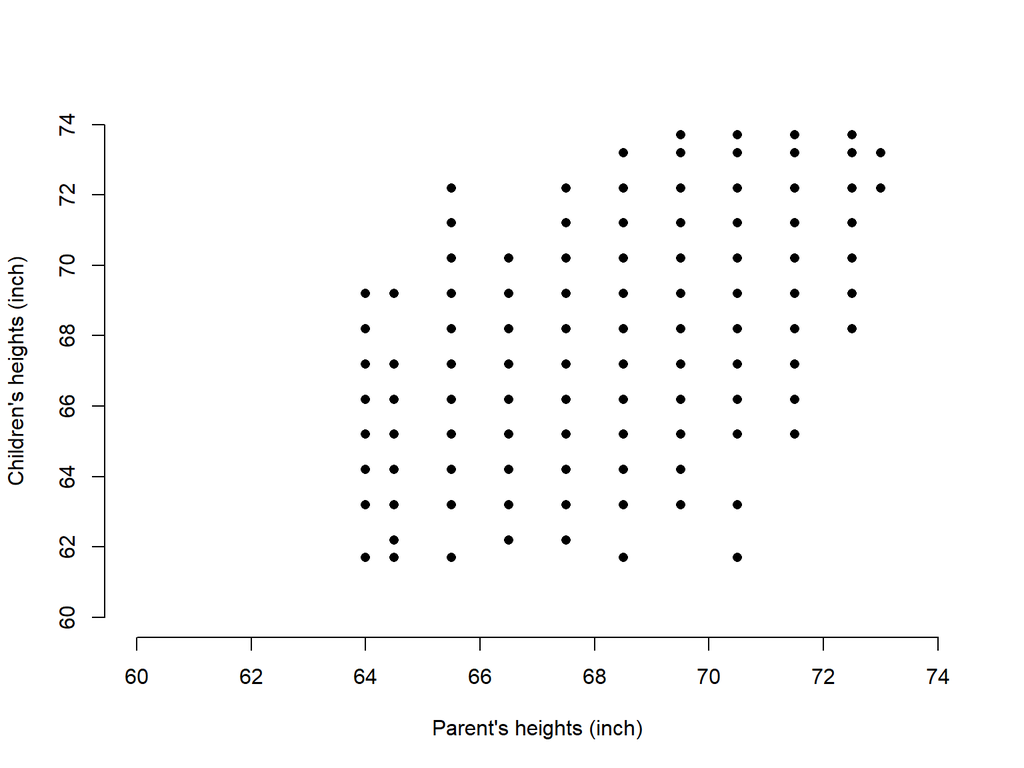

```r
plot(Galton$parent, Galton$child, xlim = c(60, 74), ylim = c(60,74), xlab= "Parent's heights (inch)", ylab = "Children's heights (inch)", bty = "n", pch = 16)
```

### **The Server.R Code**

```r
# Define server logic required to draw a scatter plot

library(shiny)
library(HistData)

shinyServer(function(input, output){
    model1 <- lm(child ~ parent, data = Galton)

    model1pred <- reactive({
        parentInput <- input$sliderparent
        predict(model1, newdata = data.frame(parent = parentInput))
    })

    output$plot1 <- renderPlot({
        parentInput <- input$sliderparent

        plot(Galton$parent, Galton$child, xlim = c(60, 74), ylim = c(60,74), xlab= "Parent's heights (inch)", ylab = "Children's heights (inch)", bty = "n", pch = 16)
        if(input$showModel1){
            abline(model1, col = "red", lwd = 2)
        }

        legend(1.5, 90, "Linear Model Prediction", col = c("red", "blue"), lwd = c(2,2), bty = "n", cex = 1.2)
        points(parentInput, model1pred(), col = "red", pch = 16, cex = 1.6)
    })

    output$pred1 <- renderText({
        round(model1pred(),2)
    })
})
```

### *References*

Galton, F. (1886). Regression Towards Mediocrity in Hereditary Stature Journal of the Anthropological Institute, 15, 246-263

**Thank you!!**

**Emily Silva Araujo**